# Gathering and Manipulation of Structured Data

March 7, 2018

## Organizing data

- Can we always plot the data without reorganizing it?
- There are two types of reorganizations
  - reshape the data
  - transform the data
- Reshaping the data is needed when we want to map the variable to an aesthetic but variable is not explicitly available
- Transforming is needed when some theoretical/ mathematical model is fitted or associated with the data

## Data in wide form

- What are the variables in the table shown below?

| year | online-sale | store-sale |
| --- | --- | --- |
| 2010 | 20 | 25 |
| 2011 | 24 | 31 |
| 2012 | 35 | 40 |

- This is a **wide form** table
- Are the variables in the table same as the variables in the plot?

```r
ggplot(dat, aes(year, sales, color=type)) +
  geom_line()
```

- What are the variables in the data that produces the plot below?

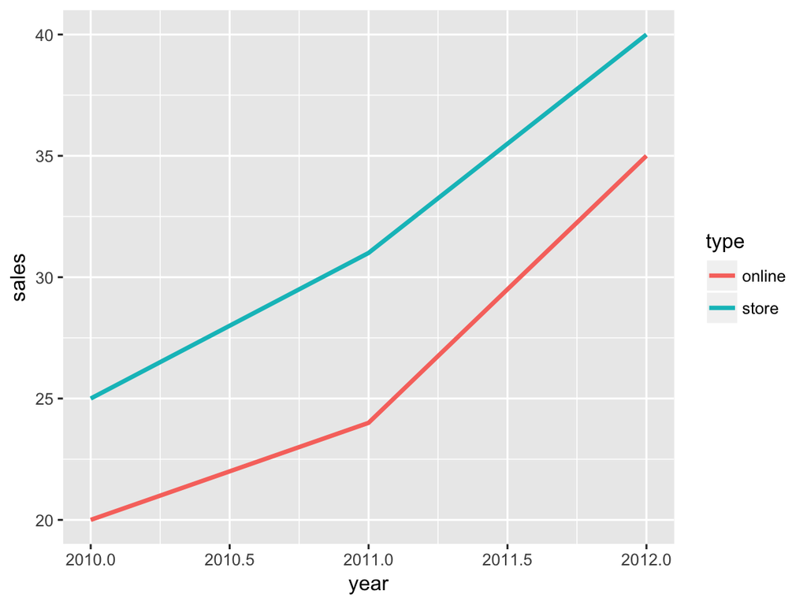

## Data in long form

- What are the variables in the table shown below?

| year | sales | type |
| --- | --- | --- |
| 2010 | 20 | online |
| 2011 | 24 | online |
| 2012 | 35 | online |
| 2010 | 25 | store |
| 2011 | 31 | store |
| 2012 | 40 | store |

- This is a **long form** table
- Are the variables in the table same as the variables in the plot?
- What are the variables in the data that produces the plot below?

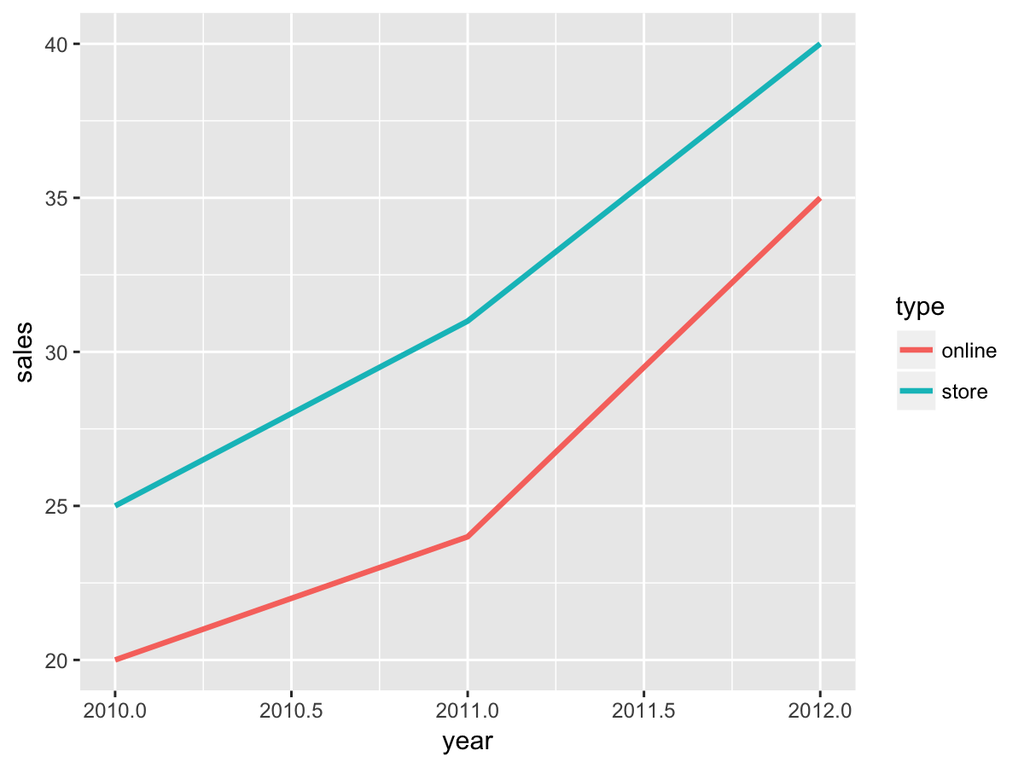

## Long vs wide form data

- How can we switch between long form and wide form of data
  - `install.packages(rehsape2)`
  - there are two functions
    - `melt()` melts data to long form
    - `dcast()` shapes molten data to wide form
- `cast()` function has some other variations
  - `acast()` is for array type data
  - `dcast()` is for data frame

## Long vs wide form data

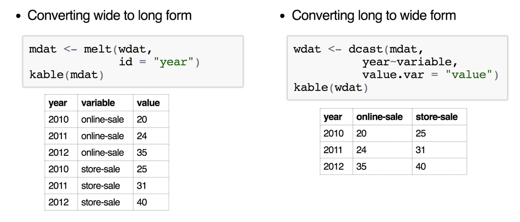

## French fries data

- Some data from `R` data frame `french_fries`

```
##  time treatment subject rep potato buttery grassy rancid painty
##     1         1       3   1    2.9     0.0    0.0    0.0    5.5
##     1         1       3   2   14.0     0.0    0.0    1.1    0.0
##     1         1      10   1   11.0     6.4    0.0    0.0    0.0
##     1         1      10   2    9.9     5.9    2.9    2.2    0.0
##     1         1      15   1    1.2     0.1    0.0    1.1    5.1
##     1         1      15   2    8.8     3.0    3.6    1.5    2.3
```

- How many variables does this table show? How many actual variables does it have?
- Variable attributes are
  - 3 different oils (treatment), 10 different days (time)
  - 12 subjects, 2 different fryers (rep)
  - 5 sensory attributes such as potato, buttery etc.

## French fries data

- Some data from `R` data frame `french_fries`

```
##  time treatment subject rep potato buttery grassy rancid painty
##     1         1       3   1    2.9     0.0    0.0    0.0    5.5
##     1         1       3   2   14.0     0.0    0.0    1.1    0.0
##     1         1      10   1   11.0     6.4    0.0    0.0    0.0
##     1         1      10   2    9.9     5.9    2.9    2.2    0.0
##     1         1      15   1    1.2     0.1    0.0    1.1    5.1
##     1         1      15   2    8.8     3.0    3.6    1.5    2.3
```

- How can we visualize the relationships between replication 1 and 2 for each of the sensory attributes?
- Discuss with your neighbor and prepare a plan.

## French fries data

- Some data from `R` data frame `french_fries`

```
##  time treatment subject rep potato buttery grassy rancid painty
##     1         1       3   1    2.9     0.0    0.0    0.0    5.5
##     1         1       3   2   14.0     0.0    0.0    1.1    0.0
##     1         1      10   1   11.0     6.4    0.0    0.0    0.0
##     1         1      10   2    9.9     5.9    2.9    2.2    0.0
##     1         1      15   1    1.2     0.1    0.0    1.1    5.1
##     1         1      15   2    8.8     3.0    3.6    1.5    2.3
```

- How can we visualize the relationships between replication 1 and 2 for each of the sensory attributes?
- Discuss with your neighbor and prepare a plan.
- Solution: generate scatterplot of rep1 vs rep2
  - we need to melt the data, except time, treatment, subject and rep
  - finally cast the data as the form we want to create scatterplot

## Molten French fries data

- first we melt the french_fries data

```r
molten_fries <- melt(french_fries, id=1:4)
print(head(molten_fries), row.names=FALSE)
```

```
##  time treatment subject rep variable value
##     1         1       3   1   potato   2.9
##     1         1       3   2   potato  14.0
##     1         1      10   1   potato  11.0
##     1         1      10   2   potato   9.9
##     1         1      15   1   potato   1.2
##     1         1      15   2   potato   8.8
```

- now we need two variables rep1 and rep2 for the scatterplot
- we can do this by casting this molten data
- while casting we need to keep variables time treatment subject intact

## Casting French fries data

- we used formula `time + treatment + subject + variable ~ rep`
- it allows us to fix variables time, treatment, subject and variable
- it creates two new columns 1 and 2

```r
cast_fries <- dcast(molten_fries, time + treatment + subject + variable~rep,
                    mean, value.var="value", na.rm=TRUE)
head(cast_fries)
```

```
##   time treatment subject variable    1    2
## 1    1         1       3   potato  2.9 14.0
## 2    1         1       3  buttery  0.0  0.0
## 3    1         1       3   grassy  0.0  0.0
## 4    1         1       3   rancid  0.0  1.1
## 5    1         1       3   painty  5.5  0.0
## 6    1         1      10   potato 11.0  9.9
```

## Casting French fries data

- we rename those new columns to be rep1 and rep2

```r
colnames(cast_fries) <- c("time", "treatment", "subject" , "variable", "rep1","rep2")
head(cast_fries)
```

```
##   time treatment subject variable rep1 rep2
## 1    1         1       3   potato  2.9 14.0
## 2    1         1       3  buttery  0.0  0.0
## 3    1         1       3   grassy  0.0  0.0
## 4    1         1       3   rancid  0.0  1.1
## 5    1         1       3   painty  5.5  0.0
## 6    1         1      10   potato 11.0  9.9
```

- now the data is ready to be plotted

## Plotting French fries data

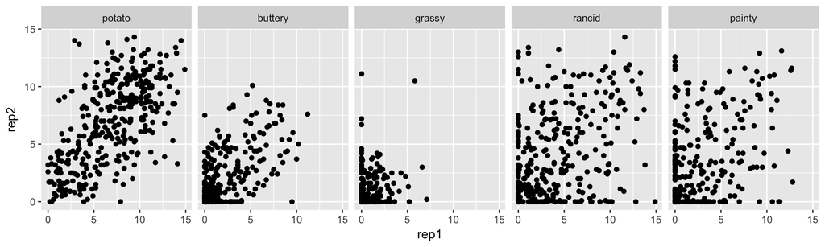

```r
ggplot(cast_fries, aes(rep1, rep2)) +
  geom_point() +
  facet_wrap(~variable, nrow=1)
```

- The correlation looks strong for potatoey and buttery, and poor for rancid and painty

## Plotting French fries data

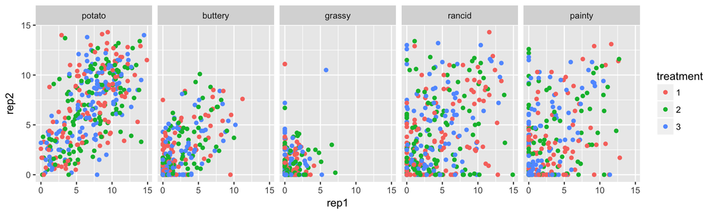

```r
ggplot(cast_fries, aes(rep1, rep2, color=treatment)) +
  geom_point() +
  facet_wrap(~variable, nrow=1)
```

- Similar behavior is observed for each treatment

## Transforming data

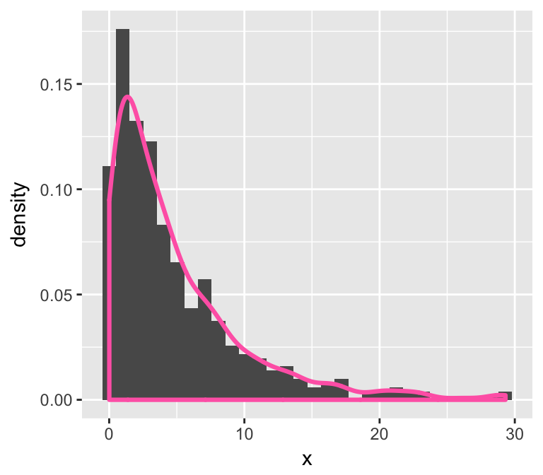

```r
ggplot(sdat, aes(x)) +
  geom_histogram(aes(y = ..density..))+
  geom_density(color='hotpink', size=1.1)
```

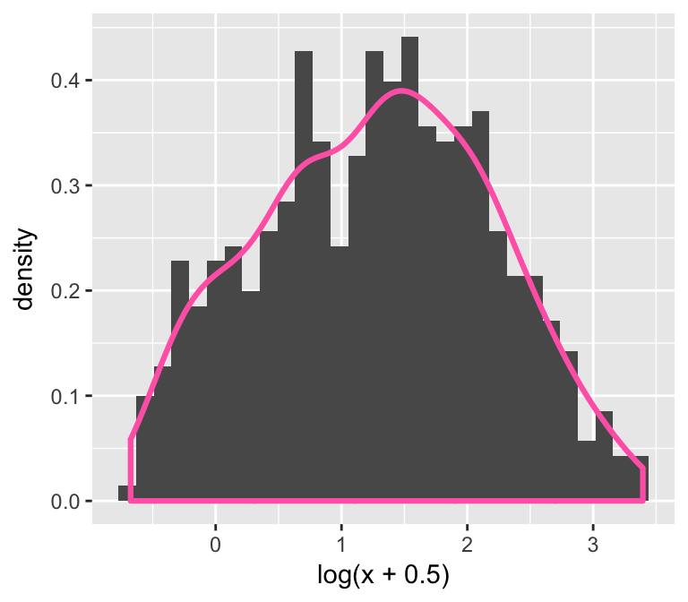

```r
ggplot(sdat, aes(log(x+0.5))) +
  geom_histogram(aes(y = ..density..))+
  geom_density(color='hotpink', size=1.1)
```

## Transforming data

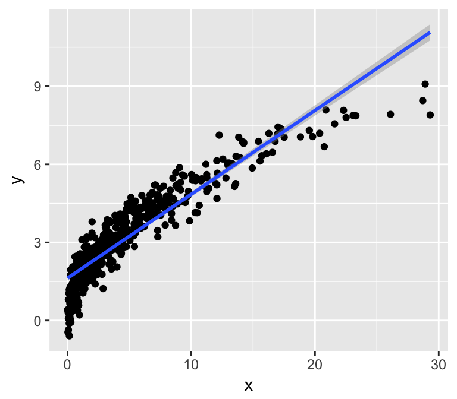

```r
ggplot(sdat, aes(x,y)) +
  geom_point() +
  geom_smooth(method="lm")
```

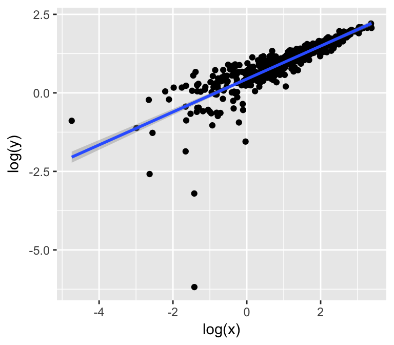

```r
ggplot(sdat, aes(log(x),log(y))) +
  geom_point() +
  geom_smooth(method="lm")
```

## Common transformations

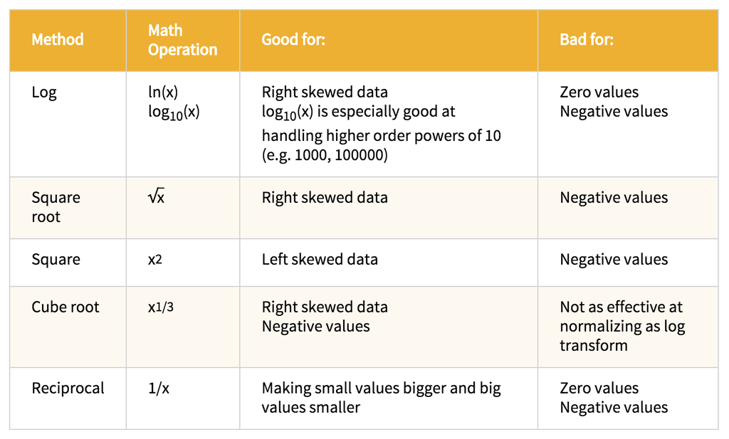

Source: https://infoactive.co/data-design/ch11.html

### Standardization of data

- To compare the similarity of distributions of data in different scales
- Types
  - Scale standardization (eg. percentage)
  - Location standardization
  - Scale and location \[y = \frac{x- \mu}{\sigma}\]
  - Compare quantiles (QQ-plot)
- The goal is to compare shapes of the distribution not actual distribution

## Crime type vs state

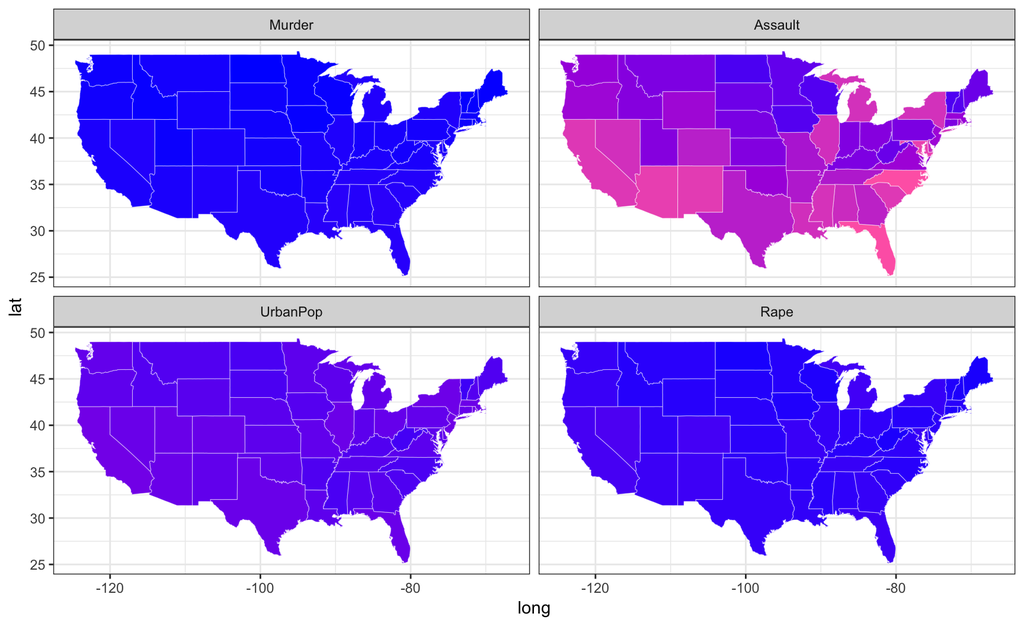

## After standardization

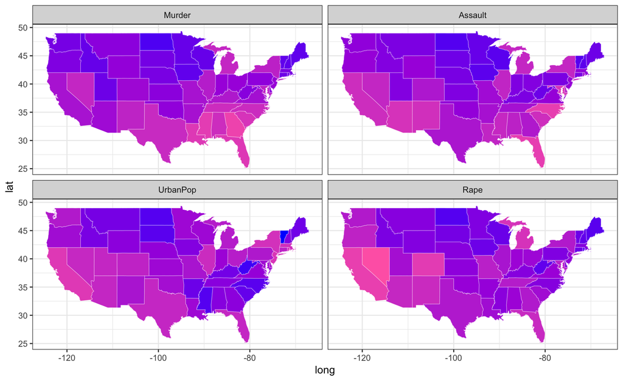

## Aggregating data


## Package dplyr

- Fast aggregation of large data (e.g. 100GB in RAM)

```r
## install.packages("dplyr")
library(dplyr)
```

- Provides functions of these verbs
- `filter()`
- `select()`
- `arrange()`
- `mutate()`
- `summarize()`
- Other important functions
- `group_by()`
- `summarise_each()`

## Piping or chain operation

- Filter then select then arrange then mutate
  - We can do all these steps on the fly
  - Piping `%>%` like UNIX pipe `|`

```r
tips %>%
  filter(size > 5) %>%
  select(total_bill, tip, sex, day, size) %>%
  arrange(tip) %>%
  mutate(tiprate = tip/total_bill)
```

```
##   total_bill tip    sex  day size   tiprate
## 1      29.80 4.2 Female Thur    6 0.1409396
## 2      27.05 5.0 Female Thur    6 0.1848429
## 3      48.17 5.0   Male  Sun    6 0.1037990
## 4      34.30 6.7   Male Thur    6 0.1953353
```

## Complex chain operation

```r
tips %>%
  filter(size > 3) %>%
  select(total_bill, tip, sex, day, size) %>%
  arrange(tip) %>%
  mutate(tiprate=tip/total_bill) %>%
    select(total_bill, tip, sex, day, tiprate) %>%
    group_by(sex, day) %>%
    summarise_each(funs(mean)) %>%
    filter(tiprate > 0.12)
```

```
## # A tibble: 5 x 5
## # Groups:   sex [2]
##   sex    day   total_bill   tip tiprate
##   <fct>  <fct>      <dbl> <dbl>   <dbl>
## 1 Female Sun         29.9  4.54   0.152
## 2 Female Thur        31.8  4.46   0.142
## 3 Male   Sat         30.5  4.26   0.140
## 4 Male   Sun         27.1  4.00   0.152
## 5 Male   Thur        30.8  4.92   0.165
```

## Joining or merging data

- Package `dplyr` joining functions
  - inner_join
  - left_join
  - semi_join
  - anti_join
- Generate two dataframes `DT` and `W`
  - Join `DT` and `W` only with matching column `x`.

```r
DT <- data.frame(x = rep(
  c("a","b","c"), times=c(3,2,2)),
  y = 10:16, v = 1:7)
W <- data.frame(x=c("b","c","d"),
                foo=c(4,2,9))
```

```r
DT
```

```
##   x  y v
## 1 a 10 1
## 2 a 11 2
## 3 a 12 3
## 4 b 13 4
## 5 b 14 5
## 6 c 15 6
## 7 c 16 7
```

```r
W
```

```
##   x foo
## 1 b   4
## 2 c   2
## 3 d   9
```

## Joining or merging data

```r
inner_join(DT,W)
```

```
##   x  y v foo
## 1 b 13 4   4
## 2 b 14 5   4
## 3 c 15 6   2
## 4 c 16 7   2
```

- Some rows of `DT` and `W` are not returned.

```r
left_join(DT,W)
```

```
##   x  y v foo
## 1 a 10 1  NA
## 2 a 11 2  NA
## 3 a 12 3  NA
## 4 b 13 4   4
## 5 b 14 5   4
## 6 c 15 6   2
## 7 c 16 7   2
```

## Joining or merging data

```r
anti_join(DT,W)
```

```
##   x  y v
## 1 a 10 1
## 2 a 11 2
## 3 a 12 3
```

- `anti_join()` joins and subsets the data on the left dataframe
  - such that it does not exist in the other dataframe

```r
semi_join(DT,W)
```

```
##   x  y v
## 1 b 13 4
## 2 b 14 5
## 3 c 15 6
## 4 c 16 7
```

## Complete cases and duplication

```r
df <- data.frame(
    x = c(1:3,2,4),
    y=c("A","B",NA,"B","D"))
df
```

```
##   x    y
## 1 1    A
## 2 2    B
## 3 3 <NA>
## 4 2    B
## 5 4    D
```

```r
df %>% filter(
  complete.cases(df))
```

```
##   x y
## 1 1 A
## 2 2 B
## 3 2 B
## 4 4 D
```

```r
df %>% filter(
  complete.cases(df)) %>%
  filter(!duplicated(cbind(x,y)))
```

```
##   x y
## 1 1 A
## 2 2 B
## 3 4 D
```

## Example codes (US crime map)

```r
library(maps)
library(reshape2)
library(dplyr)
mdat <- map_data("state")
state <- tolower(row.names(USArrests))
arrest <- data.frame(state, USArrests, stringsAsFactors = FALSE)
odat <- left_join(mdat, arrest, by = c('region' = 'state')) %>%
  arrange(order)
sdat <- subset(odat, select=c("long", "lat", "group", "region", "Murder",
                               "Assault", "UrbanPop",  "Rape" ))

msdat <- melt(sdat, id=c("long", "lat", "group", "region"))

ggplot(msdat, aes(x=long, y=lat,group=group)) +
  geom_polygon(aes(fill=value), colour = alpha("white", 1/2), size = 0.2) +
  theme_bw() + theme(legend.position = "none") + facet_wrap(~variable) +
  scale_fill_continuous(low="blue", high="hotpink")
```

## Example codes (Crime with standardisation of data)

```r
library(scales)
std_crime <- scale(USArrests)
arrest <- data.frame(state, std_crime, stringsAsFactors = FALSE)
odat <- left_join(mdat, arrest, by = c('region' = 'state')) %>%
  arrange(order)
sdat <- subset(odat, select=c("long", "lat", "group", "region", "Murder",
                               "Assault", "UrbanPop",  "Rape" ))

msdat <- melt(sdat, id=c("long", "lat", "group", "region"))

ggplot(msdat, aes(x=long, y=lat,group=group)) +
  geom_polygon(aes(fill=value), colour = alpha("white", 1/2), size = 0.2) +
  theme_bw() + theme(legend.position = "none") + facet_wrap(~variable) +
  scale_fill_continuous(low="blue", high="hotpink")
```

## References

- Read chapter 4 of [*Modern Data Science with R*](https://www.crcpress.com/Modern-Data-Science-with-R/Baumer-Kaplan-Horton/p/book/9781498724487) by Baumer et. al.
- Documentation on dplyr from RStudio  
  http://cran.rstudio.com/web/packages/dplyr/vignettes/introduction.html
- Reshaping Data with the reshape Package  
  http://www.jstatsoft.org/v21/i12/paper